# Omega PLC

Shivant Maharaj

2022-09-19

# Introduction

The following assessment was given as a classroom exercise to test our understanding of R, Version Control, and Visualisations using GGPlot2.

# Omega Group plc- Pay Discrimination

At the last board meeting of Omega Group Plc., the headquarters of a large multinational company, the issue was raised that women were being discriminated in the company, in the sense that the salaries were not the same for male and female executives.

We were asked to carry out the analysis to find out whether there is a significant difference between the salaries of men and women, and if there are any discrimination factors.

## Loading the data

Omega Group Plc. had shared data of 50 employees with us. The data was inspected before conducting our analysis and we have noted that there were no missing/incomplete data points.

```r
omega <- read_csv(here::here("data", "omega.csv"))
skimr::skim(omega) # examine the data frame
```

Data summary

| Name | omega |
| --- | --- |
| Number of rows | 50 |
| Number of columns | 3 |
| _______________________ |  |
| Column type frequency: |  |
| character | 1 |
| numeric | 2 |
| ________________________ |  |
| Group variables | None |

**Variable type: character**

| skim_variable | n_missing | complete_rate | min | max | empty | n_unique | whitespace |
| --- | --- | --- | --- | --- | --- | --- | --- |
| gender | 0 | 1 | 4 | 6 | 0 | 2 | 0 |

**Variable type: numeric**

| skim_variable | n_missing | complete_rate | mean | sd | p0 | p25 | p50 | p75 | p100 | hist |
| --- | --- | --- | --- | --- | --- | --- | --- | --- | --- | --- |
| salary | 0 | 1 | 68717.06 | 8638.16 | 47032.57 | 63303.16 | 68847.02 | 74777.66 | 84576.11 | ▁▃▇▆▅ |
| experience | 0 | 1 | 13.98 | 11.87 | 0.00 | 2.25 | 15.00 | 20.75 | 44.00 | ▇▃▅▂▁ |

## Relationship Salary - Gender ?

The data frame `omega` contains the salaries for the sample of 50 executives in the company.

We have constructed a visualization that shows the salary trend between male and female employees:

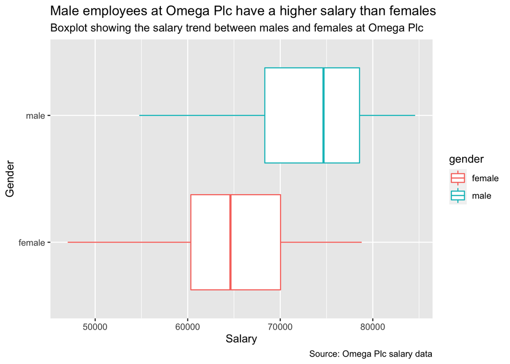

```r
#Extra Visual
ggplot(omega) +
  geom_boxplot() +
  aes(x = salary, y = gender, colour = gender) +
  labs (x = "Salary", y = "Gender", caption = "Source: Omega Plc salary data", title = "Male employees at Omega Plc have a higher salary than females", subtitle = "Boxplot showing the salary trend between males and females at Omega Plc")
```

The above graph shows a visual difference between the average distributions of salary between female and male salary’s for Omega Plc. The group decided to extrapolate the data and construct tables depict these initial findings.

```r
# Summary Statistics of salary by gender
mosaic::favstats (salary ~ gender, data=omega)
```

```
##   gender      min       Q1   median       Q3      max     mean       sd  n
## 1 female 47032.57 60337.83 64618.21 70033.15 78800.18 64542.84 7567.265 26
## 2   male 54768.19 68331.31 74674.51 78568.11 84576.11 73239.13 7462.599 24
##   missing
## 1       0
## 2       0
```

```r
#Summary Stats

summary_stats <- omega %>%
  group_by(gender) %>%
  summarise(mean_salary = mean(salary),
            sd_salary = sd(salary),
            count = n(),
            t_critical = qt(0.975, count-1),
            se_salary = sd(salary)/sqrt(count),
            margin_of_error = t_critical * se_salary,
            salary_low = mean_salary - margin_of_error,
            salary_high = mean_salary + margin_of_error)

summary_stats
```

```
## # A tibble: 2 × 9
##   gender mean_salary sd_salary count t_critical se_sal…¹ margi…² salar…³ salar…⁴
##   <chr>        <dbl>     <dbl> <int>      <dbl>    <dbl>   <dbl>   <dbl>   <dbl>
## 1 female      64543.     7567.    26       2.06    1484.   3056.  61486.  67599.
## 2 male        73239.     7463.    24       2.07    1523.   3151.  70088.  76390.
## # … with abbreviated variable names ¹se_salary, ²margin_of_error, ³salary_low,
## #   ⁴salary_high
```

```r
obs_diff <- omega %>%
  specify(salary ~ gender) %>%
  calculate(stat = "diff in means", order = c("male", "female"))
# Dataframe with two rows (male-female) and having as columns gender, mean, SD, sample size,
# the t-critical value, the standard error, the margin of error,
# and the low/high endpoints of a 95% condifence interval

p_val <- summary_stats %>%
  get_p_value(obs_stat = obs_diff, direction = "two_sided")
p_val
```

```
## # A tibble: 1 × 1
##   p_value
##     <dbl>
## 1       0
```

From the initial analysis in the table above, it is shown that males have a higher mean salary of 8696 than females. We decided that more analysis is required to determine if this difference is significant and to decide if there are any further analysis required to uncover influencing factors.

### Advanced Analysis

The team decided to conduct 2 tests to decide if the difference in mean salary’s between males and females were significant. The following tests were decided upon:

1. Hypothesis Tesing useing the T Test package
2. T Test using simulation method and infer packages

#### Hypothesis Tesing using the T Test package

The T Test package was used to assess if there is a true difference in the salaries, and findings form this built-in test shows that there is indeed a significant difference as indicated by the absolute T-Value being greater than 1.96, and the P-Value being smaller than 5%.

```r
# hypothesis testing using t.test()
t.test(salary ~ gender, data = omega)
```

```
##
##  Welch Two Sample t-test
##
## data:  salary by gender
## t = -4.0891, df = 47.78, p-value = 0.0001651
## alternative hypothesis: true difference in means between group female and group male is not equal to 0
## 95 percent confidence interval:
##  -12972.825  -4419.755
## sample estimates:
## mean in group female   mean in group male
##             64542.84             73239.13
```

We also ran a hypothesis test, assuming that the mean difference in salaries is zero as the null hypothesis using the simulation method from the `infer` package.

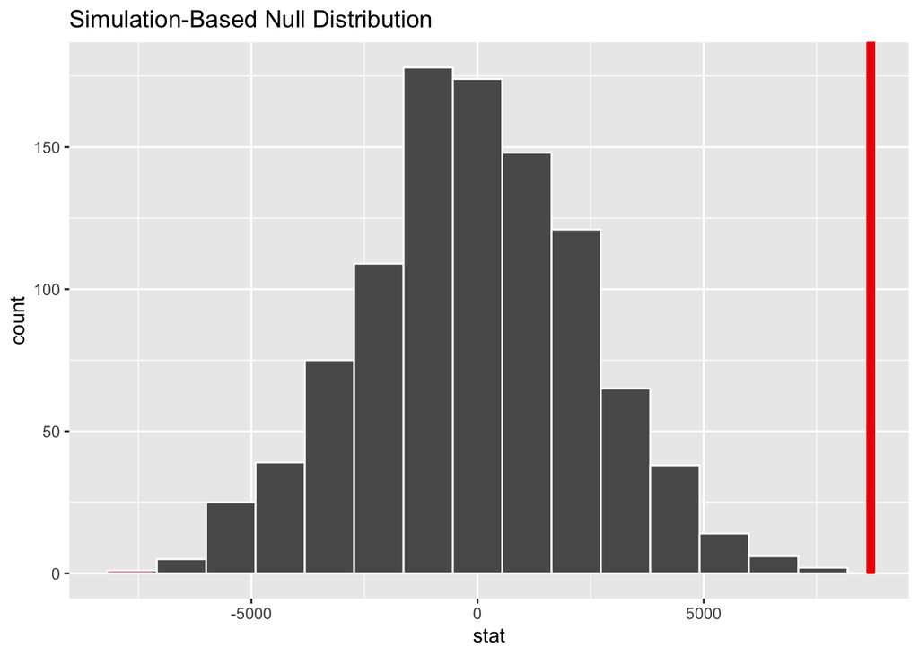

```r
# hypothesis testing using infer package
library(infer)
set.seed(1234)
infer_stats <- omega %>%
  specify(salary ~ gender) %>%
  hypothesize(null = "independence",) %>%
  generate(reps = 1000, type ="permute") %>%
  calculate(stat = "diff in means", order = c("male", "female"))

percentile_ci <- infer_stats %>% get_confidence_interval(level = 0.95, type = "percentile")

visualize(infer_stats) + shade_p_value(obs_stat = obs_diff, direction = "two-sided")
```

```r
percentile_ci
```

```
## # A tibble: 1 × 2
##   lower_ci upper_ci
##      <dbl>    <dbl>
## 1   -5025.    4829.
```

From both tests conducted, we can conclude that the observed difference in the means of salaries between males and females at Omega Plc is indeed a significant difference.

As depicted in the simulation density visualisation above, we can see that the observed difference is passed the Upper 95% percentile of 4829. This is confirmed by the t.test() performed that states the absolute T-value as 4, which is much bigger than the standard acceptable value of 1.96. Additionally, the p-value was smaller than 1%.

## Relationship Experience - Gender?

At the board meeting, someone raised the issue that there was indeed a substantial difference between male and female salaries, but that this was attributable to other reasons such as differences in experience. A questionnaire send out to the 50 executives in the sample reveals that the average experience of the men is approximately 21 years, whereas the women only have about 7 years experience on average (see table below).

```r
# Summary Statistics of experience by gender
favstats (experience ~ gender, data=omega)
```

```
##   gender min    Q1 median    Q3 max      mean       sd  n missing
## 1 female   0  0.25    3.0 14.00  29  7.384615  8.51388 26       0
## 2   male   1 15.75   19.5 31.25  44 21.125000 10.91593 24       0
```

```r
#Summary Stats
summary_stats_exp <- omega %>%
  group_by(gender) %>%
  summarise(mean_experience = mean(experience),
            sd_experience = sd(experience),
            count = n(),
            t_critical = qt(0.975, count-1),
            se_experience = sd(experience)/sqrt(count),
            margin_of_error = t_critical * se_experience,
            experience_low = mean_experience - margin_of_error,
            experience_high = mean_experience + margin_of_error)

summary_stats_exp
```

```
## # A tibble: 2 × 9
##   gender mean_experience sd_expe…¹ count t_cri…² se_ex…³ margi…⁴ exper…⁵ exper…⁶
##   <chr>            <dbl>     <dbl> <int>   <dbl>   <dbl>   <dbl>   <dbl>   <dbl>
## 1 female            7.38      8.51    26    2.06    1.67    3.44    3.95    10.8
## 2 male             21.1      10.9     24    2.07    2.23    4.61   16.5     25.7
## # … with abbreviated variable names ¹sd_experience, ²t_critical,
## #   ³se_experience, ⁴margin_of_error, ⁵experience_low, ⁶experience_high
```

The above data shows a difference in experience mean of 13.74 years between females and males. To establish if the observation is a significant difference, further analysis is required.

```r
t.test(experience ~ gender, data = omega)
```

```
##
##  Welch Two Sample t-test
##
## data:  experience by gender
## t = -4.9348, df = 43.472, p-value = 1.225e-05
## alternative hypothesis: true difference in means between group female and group male is not equal to 0
## 95 percent confidence interval:
##  -19.353881  -8.126888
## sample estimates:
## mean in group female   mean in group male
##             7.384615            21.125000
```

Further analysis was conducted in the form of a T Test to assess the if there is any significant differences in experience between genders. The following test show the statistical variables for Omega Plc.The findings show that there is a significant difference in the experience between males and females from Omega Plc, shown by the observed t-value is greater than 1.96 and a small p-value. This finding assists in validating the pervious observation - as the average experience of males suggests reason as to why the salaries of genders are different.

Based on this evidence, can you conclude that there is a significant difference between the experience of the male and female executives? Perform similar analyses as in the previous section. Does your conclusion validate or endanger your conclusion about the difference in male and female salaries?

## Relationship Salary - Experience ?

To further substantiate the findings from the previous tests conducted, a final visual check is performed to determine if there have been any discrimination against females at Omega Plc.

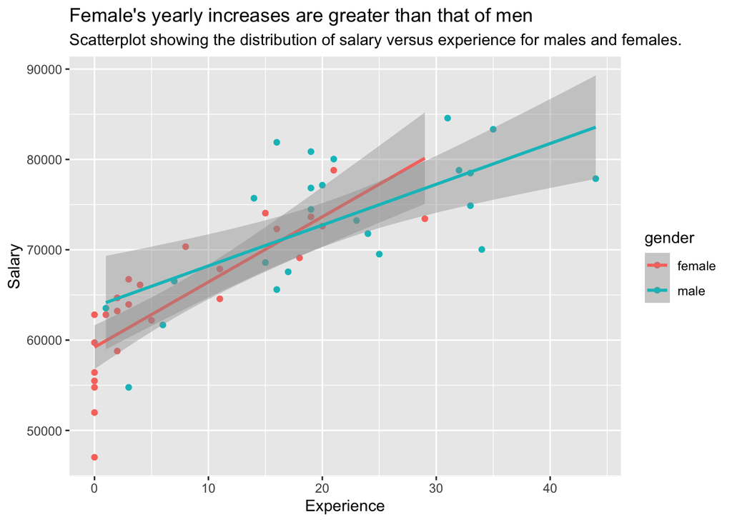

```r
ggplot(omega)+
  aes(x = experience, y = salary, color = gender)+
  geom_point() +
  geom_smooth(method = "lm") +
  labs(x = "Experience", y = "Salary", title = "Female's yearly increases are greater than that of men", subtitle = "Scatterplot showing the distribution of salary versus experience for males and females.")
```

The plot shows that there are a greater proportion of female employees at Omega Plc with less than 10 years of experience as compared to males, while there is a greater proportion of males with more than 10 years of experience than females at the company

## Correlation checks between gender, experience, and salary

The following graph shows a visual matrix of how gender and experience affect salary.

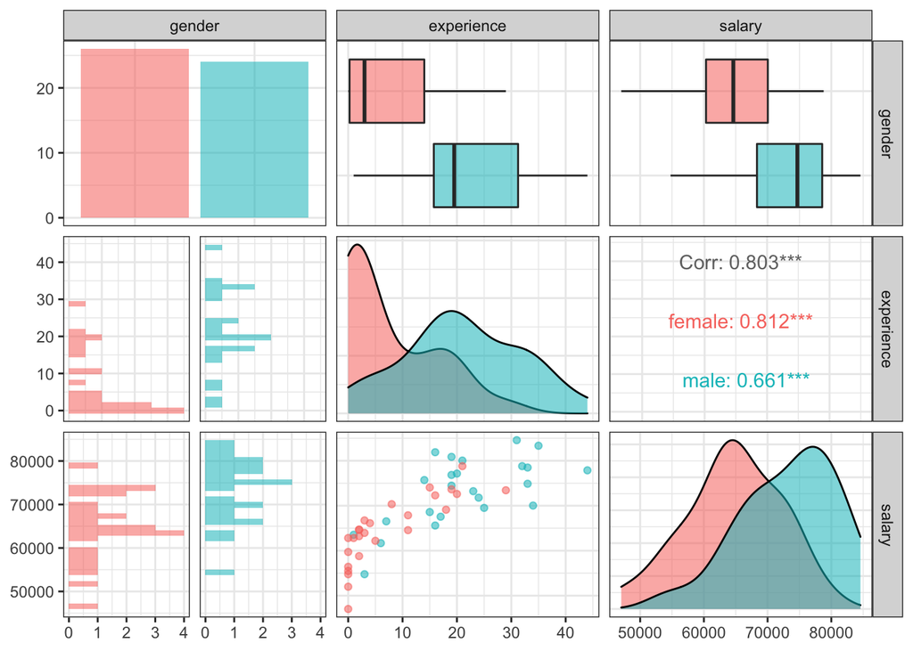

```r
omega %>%
  select(gender, experience, salary) %>% #order variables they will appear in ggpairs()
  ggpairs(aes(colour=gender, alpha = 0.3))+
  theme_bw()
```

The visual assessing salary and experience for various genders shows the same finding as described in the visual before.